# GDP and Income Levels for Countries Using World Bank Data

Georges Michel, Jack Nelson, Nicole Shaver, Nathan Tuttle  
February 25, 2017

## Introduction

In this study, we will examine the Gross Domestic Product (GDP) rankings for countries across the world and analyze the relationship between GDP and income groups. We will order the countries by GDP and evaluate the average GDP ranking for different income groups, visualize the GDP data for all countries by income group, and examine the relationship between income group and GDP. The analysis will utilize GDP and income group from the data-catalog at the world bank web site.

## Code used to download, tidy and merge the data

```r
dir<-getwd()
source(paste(dir,"/source/download.R",sep=""))
source(paste(dir,"/source/cleanup_ED_GDP.R",sep=""))
source(paste(dir,"/source/merge_ED_GDP.R",sep=""))
```

## Analysis Results

Q1. After merging the GDP and education datasets by on country code, 189 of the IDs match between the two datasets, as shown in the structure of the dataframe below. The data frame has 189 rows after merging education data and excluding N/A values.

```r
#The code below will use the str command to describe the number of observations in the dataset. Rows where the country code did not match were exluded by this line in merge_ED_GDP.R--combo2<-subset(combo,!is.na(Long.Name) & !is.na(GDP.Country))
str(combo2)
```

```
## 'data.frame':    189 obs. of  34 variables:
##  $ CountryCode                                      : chr  "ABW" "AFG" "AGO" "ALB" ...
##  $ GDP.ranking                                      : num  161 105 60 125 32 26 133 172 12 27 ...
##  $ GDP.Country                                      : chr  "Aruba" "Afghanistan" "Angola" "Albania" ...
##  $ GDP                                              : num  2584 20497 114147 12648 348595 ...
##  $ Long.Name                                        : chr  "Aruba" "Islamic State of Afghanistan" "People's Republic of Angola" "Republic of Albania" ...
##  $ Income.Group                                     : chr  "High income: nonOECD" "Low income" "Lower middle income" "Upper middle income" ...
##  $ Region                                           : chr  "Latin America & Caribbean" "South Asia" "Sub-Saharan Africa" "Europe & Central Asia" ...
##  $ Lending.category                                 : chr  NA "IDA" "IDA" "IBRD" ...
##  $ Other.groups                                     : chr  NA "HIPC" NA NA ...
##  $ Currency.Unit                                    : chr  "Aruban florin" "Afghan afghani" "Angolan kwanza" "Albanian lek" ...
##  $ Latest.population.census                         : chr  "2000" "1979" "1970" "2001" ...
##  $ Latest.household.survey                          : chr  NA "MICS, 2003" "MICS, 2001, MIS, 2006/07" "MICS, 2005" ...
##  $ Special.Notes                                    : chr  NA "Fiscal year end: March 20; reporting period for national accounts data: FY." NA NA ...
##  $ National.accounts.base.year                      : chr  "1995" "2002/2003" "1997" NA ...
```

[output cut: 20 more lines]

Q2. The country with the 13th lowest GDP (determined by sorting the data in ascending order by GDP, placing the United States last) is St. Kitts and Nevis. There were no NA values in the GDP column. The result below is the 13th row of a table sorted in ascending order by GDP.

```r
# The code below will sort the table in ascending order by GDP, pick out the 13th row and key columns from the resulting dataframe, display the 13th row, and count the number of NAs in the GDP column.
sorted_GDP<-combo2[order(combo2$GDP),]
GDP_13<-sorted_GDP[13,c(1,2,3,4)]
GDP_13
```

```
##     CountryCode GDP.ranking         GDP.Country GDP
## 109         KNA         178 St. Kitts and Nevis 767
```

```r
sum(is.na(sorted_GDP$GDP))
```

```
## [1] 0
```

Q3. The table below summarizes the average GDP ranking for the "High income: OECD" and "High income: nonOECD" groups. The average GDP ranking for the "High income: OECD" group is 32.96667. The average GDP ranking for the "High income: nonOECD" group is 91.91304. There were no NAs in the GDP ranking column.

```r
# The code below will create a subset dataframe containing only 'High income: OECD' and 'High income: nonOECD' income group countries. It will then take the average GDP.ranking by income group of the subset with NA values removed, and count the number of NA values in the GDP ranking.
combo2.HighIncome <- subset(combo2, combo2$Income.Group == 'High income: OECD' | combo2$Income.Group == 'High income: nonOECD')
aggregate(combo2.HighIncome$GDP.ranking~combo2.HighIncome$Income.Group, combo2.HighIncome, mean, na.rm = TRUE)
```

```
##   combo2.HighIncome$Income.Group combo2.HighIncome$GDP.ranking
## 1           High income: nonOECD                      91.91304
## 2              High income: OECD                      32.96667
```

```r
sum(is.na(combo2.HighIncome$GDP.ranking))
```

```
## [1] 0
```

Q4. Plotting the GDP for all of the countries and coloring by Income Group, we notice that countries that are part of the OECD have a higher GDP compared to non OECD countries. Visualizing the data in this way also enables us to see the outliers in each Income Group. USA and China have higher GDP than most of their respective groups while Tuvalu (TUV) has a lower GDP than the rest of its income group.

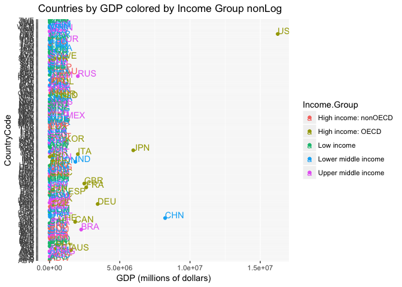

```r
#The code below will plot the GDP for all countries, on both a standard and log scale, and color by Income Group, all
#using ggplot.
ggplot(data=combo2, aes(x=GDP, y=CountryCode, color=Income.Group))+geom_point()+geom_text(aes(label=combo2$CountryCode),hjust=0, vjust=0)+ggtitle("Countries by GDP colored by Income Group nonLog")+labs(x="GDP (millions of dollars)")
```

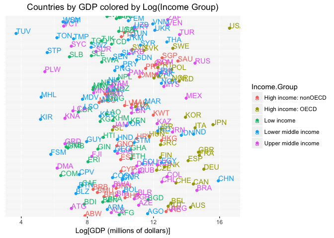

```r
ggplot(data=combo2, aes(x=log(GDP), y=CountryCode, color=Income.Group))+geom_point()+ggtitle("Countries by GDP colored by Log(Income Group)")+geom_text(aes(label=combo2$CountryCode),hjust=0, vjust=0)+ theme(axis.title.y=element_blank(),
        axis.text.y=element_blank(),
        axis.ticks.y=element_blank(),
        plot.title = element_text(hjust = 0.5))+labs(x="Log[GDP (millions of dollars)]")
```

Q5. The table below shows the Income Groups as the row names and the GDP rank groups as the column names, with the number of countries meeting both conditions in each cell of the table. The groups are defined as G0_to_20 being the 1st to 20th percentile by GDP ranking, G20_to_40 is >20th percentile to 40th percentile, etc. Thus, we see that there are a total fof 38 nations in the top 1/5th of the GDP rankings, and 5 nations within that top GDP ranking group that are classified as "Lower middle income".

```r
#The code below will make a table that doesn't have any NA for GDP.Ranking, count the number of NAs in the table, and divide the GDP ranking column into 5 quantile groups, with G0_to_20 having the lowest ranking (and thus highest GDP) and G80_to_100 having the highest GDP ranking (or lowest GDP). The code will then make a table by Income Group and ranking group and format it for easy reasing using the spread function.
ranking<-subset(combo2,!is.na(GDP.ranking))
sum(is.na(combo2$GDP.ranking))
```

```
## [1] 0
```

```r
QuantSep <- ceiling(sum(!is.na(ranking$GDP.ranking))/5)
ranking$GDP.quant.group[ranking$GDP.ranking<=QuantSep]<-"G0_to_20"
ranking$GDP.quant.group[ranking$GDP.ranking>QuantSep & ranking$GDP.ranking<=(2*QuantSep)]<-"G20_to_40"
ranking$GDP.quant.group[ranking$GDP.ranking>(2*QuantSep) & ranking$GDP.ranking<=(3*QuantSep)]<-"G40_to_60"
ranking$GDP.quant.group[ranking$GDP.ranking>(3*QuantSep) & ranking$GDP.ranking<=(4*QuantSep)]<-"G60_to_80"
ranking$GDP.quant.group[ranking$GDP.ranking>(4*QuantSep)]<-"G80_to_100"
QuantIncTable <- data.frame(table(ranking$Income.Group,ranking$GDP.quant.group))
names(QuantIncTable) <- c('IncomeGroup','Ranking','Freq')
QuantIncTable <- spread(QuantIncTable,Ranking,Freq)

QuantIncTable
```

```
##            IncomeGroup G0_to_20 G20_to_40 G40_to_60 G60_to_80 G80_to_100
## 1 High income: nonOECD        4         5         8         4          2
## 2    High income: OECD       18        10         1         1          0
## 3           Low income        0         1         9        16         11
## 4  Lower middle income        5        13        12         8         16
## 5  Upper middle income       11         9         8         8          9
```

## Conclusion

In this study of GDP and income levels, using data from the World Bank, we find that there are 189 countries from which we can make conclusions about the GDP and income levels. The High income: nonOECD groups have an average ranking of 91.91, while the High income: OECD groups have an average ranking of 32.97. Thus, within a given income group, being a member of the OECD leads to lower GDP ranking (higher GDP). Of the 38 countries with the highest GDP, five of them are classified as "Lower middle income". From this we can conclude that few countries with a high GDP are part of the lower income groups. Graphically examining GDP by country code and income group shows that countries that are part of the OECD have a higher GDP compared to non OECD countries. USA and China have higher GDP than most of their respective groups while Tuvalu (TUV) has a lower GDP than the rest of its income group.